# Machine Learning Project with ROCKET

#### 4.1.5 Naive Bayes Classifier

```python
# Parameter grid for Naive Bayes Classifier
param_grid_nb_rocket = {
    'rocket__num_kernels': [10, 50, 100, 500, 1000, 1500],
    'classifier__var_smoothing': [1e-9, 1e-8, 1e-7, 1e-6, 1e-5]
}

# Setting up the pipeline template for Naive Bayes
pipeline_template_nb_rocket = Pipeline([
    ('rocket', Rocket()),  # ROCKET transformer
    ('classifier', GaussianNB())  # Placeholder classifier
])

# Grid search setup for Naive Bayes
grid_search_nb_rocket = GridSearchCV(pipeline_template_nb_rocket, param_grid_nb_rocket, cv=tscv, scoring='accuracy', verbose=1)
grid_search_nb_rocket.fit(X3d_train, y3d_train)

# Best parameters and accuracy for Naive Bayes
best_params_nb_rocket = grid_search_nb_rocket.best_params_
best_accuracy_nb_rocket = grid_search_nb_rocket.best_score_

print("Best Parameters for Naive Bayes Classifier with ROCKET:", best_params_nb_rocket)
print("Accuracy on the training set (cross-validation) for Naive Bayes Classifier with ROCKET:", best_accuracy_nb_rocket)

# Predict on the test set with the best Naive Bayes model
y_pred_nb_rocket = grid_search_nb_rocket.predict(X3d_test)

# Evaluate accuracy on the test set
test_accuracy_nb_rocket = accuracy_score(y3d_test, y_pred_nb_rocket)
print("Accuracy on the test set for Naive Bayes Classifier with ROCKET:", test_accuracy_nb_rocket)

# Predict on the training set with the best Naive Bayes model
y_pred_train_nb_rocket = grid_search_nb_rocket.predict(X3d_train)

# Evaluate accuracy on the training set
train_accuracy_nb_rocket = accuracy_score(y3d_train, y_pred_train_nb_rocket)
print("Accuracy on the training set for Naive Bayes Classifier:", train_accuracy_nb_rocket)

# Predict on the training set with the best Naive Bayes model
y_pred_train_nb_rocket = grid_search_nb_rocket.predict(X3d_train)

# Evaluate accuracy on the training set
train_accuracy_nb_rocket = accuracy_score(y3d_train, y_pred_train_nb_rocket)
print("Accuracy on the training set for Naive Bayes Classifier:", train_accuracy_nb_rocket)
```

```
Fitting 5 folds for each of 30 candidates, totalling 150 fits
Best Parameters for Naive Bayes Classifier with ROCKET: {'classifier__var_smoothing': 1e-07, 'rocket__num_kernels': 500}
Accuracy on the training set (cross-validation) for Naive Bayes Classifier with ROCKET: 0.9
Accuracy on the test set for Naive Bayes Classifier with ROCKET: 0.9058823529411765
Accuracy on the training set for Naive Bayes Classifier: 0.8839285714285714
Accuracy on the training set for Naive Bayes Classifier: 0.8839285714285714
```

```python
# Extract the best parameters except for the number of kernels
best_params_nb = {k.split('__')[-1]: v for k, v in best_params_nb_rocket.items() if not k.startswith('rocket__num_kernels')}

# Define the number of kernels options
num_kernels_options = [10, 50, 100, 200, 300, 400, 500, 600]

# Dictionaries to store accuracy results
train_accuracy_results_nb = {}
test_accuracy_results_nb = {}

for num_kernels in num_kernels_options:
    # Create the pipeline with the specified number of kernels
    pipeline_nb = Pipeline([
        ('rocket', Rocket(num_kernels=num_kernels)),
        ('classifier', GaussianNB(**best_params_nb))
    ])

    # Fit the pipeline on the training data
    pipeline_nb.fit(X3d_train, y3d_train)

    # Evaluate on the training set
    y_pred_train_nb = pipeline_nb.predict(X3d_train)
    train_accuracy_nb = accuracy_score(y3d_train, y_pred_train_nb)
    train_accuracy_results_nb[num_kernels] = train_accuracy_nb

    # Evaluate on the test set
    y_pred_test_nb = pipeline_nb.predict(X3d_test)
    test_accuracy_nb = accuracy_score(y3d_test, y_pred_test_nb)
    test_accuracy_results_nb[num_kernels] = test_accuracy_nb

    # Print out the accuracies for each number of kernels
    print(f"Number of Kernels: {num_kernels}, Training Accuracy: {train_accuracy_nb}, Test Accuracy: {test_accuracy_nb}")
```

```
Number of Kernels: 10, Training Accuracy: 0.8839285714285714, Test Accuracy: 0.8705882352941177
Number of Kernels: 50, Training Accuracy: 0.8928571428571429, Test Accuracy: 0.8941176470588236
Number of Kernels: 100, Training Accuracy: 0.8928571428571429, Test Accuracy: 0.8823529411764706
Number of Kernels: 200, Training Accuracy: 0.9107142857142857, Test Accuracy: 0.9058823529411765
Number of Kernels: 300, Training Accuracy: 0.8898809523809523, Test Accuracy: 0.9294117647058824
Number of Kernels: 400, Training Accuracy: 0.9047619047619048, Test Accuracy: 0.9176470588235294
Number of Kernels: 500, Training Accuracy: 0.8839285714285714, Test Accuracy: 0.8705882352941177
Number of Kernels: 600, Training Accuracy: 0.9047619047619048, Test Accuracy: 0.9058823529411765
```

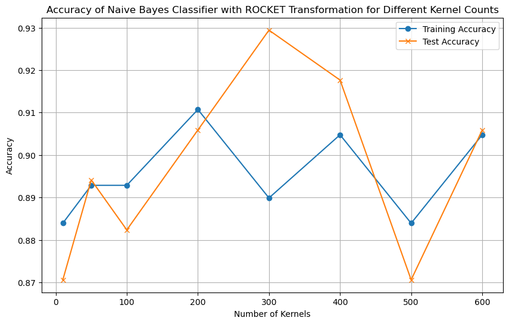

```python
# Extracted results for plotting (for Naive Bayes)
num_kernels_nb = list(train_accuracy_results_nb.keys())
train_accuracy_nb = list(train_accuracy_results_nb.values())
test_accuracy_nb = list(test_accuracy_results_nb.values())

# Plotting the results for Naive Bayes
plt.figure(figsize=(10, 6))
plt.plot(num_kernels_nb, train_accuracy_nb, label='Training Accuracy', marker='o')
plt.plot(num_kernels_nb, test_accuracy_nb, label='Test Accuracy', marker='x')
plt.xlabel('Number of Kernels')
plt.ylabel('Accuracy')
plt.title('Accuracy of Naive Bayes Classifier with ROCKET Transformation for Different Kernel Counts')
plt.legend()
plt.grid(True)
plt.show()
```

```python
# Extracting accuracies for 600 kernels
train_accuracy_nb_kernels = train_accuracy_results_nb[600]
test_accuracy_nb_kernels = test_accuracy_results_nb[600]

# Formatting accuracies to four decimal places
nb_train_accuracy = f"{train_accuracy_nb_kernels:.4f}"
nb_test_accuracy = f"{test_accuracy_nb_kernels:.4f}"

# Print formatted accuracies
print(f"Training Accuracy for 600 kernels: {nb_train_accuracy}")
print(f"Test Accuracy for 600 kernels: {nb_test_accuracy}")
```

```
Training Accuracy for 600 kernels: 0.9048
Test Accuracy for 600 kernels: 0.9059
```

```python
# Define the chosen number of kernels
chosen_num_kernels = 600

# Extract the best parameters from the grid search (excluding 'rocket__num_kernels')
best_params_nb = {k.replace('classifier__', ''): v for k, v in best_params_nb_rocket.items() if not k.startswith('rocket__num_kernels')}

# Create the pipeline with the specified number of kernels and the best Naive Bayes parameters
rocket_nb_pipeline = make_pipeline(
    Rocket(num_kernels=chosen_num_kernels),
    GaussianNB(**best_params_nb)
)

# Fit the pipeline on the training data
rocket_nb_pipeline.fit(X3d_train, y3d_train)

# Store the model for future use
stored_rocket_nb_model = rocket_nb_pipeline

# Perform cross-validation
cv_scores = cross_val_score(stored_rocket_nb_model, X3d_train, y3d_train, cv=tscv, scoring='accuracy')

# Calculate the average accuracy from cross-validation
average_accuracy_cv_nb = np.mean(cv_scores)

# Print the average cross-validation accuracy
print(f"Average Accuracy after TimeSeriesSplit cross-validation for Naive Bayes: {average_accuracy_cv_nb:.4f}")
```

```
Average Accuracy after TimeSeriesSplit cross-validation for Naive Bayes: 0.8857
```

#### 4.1.6 Ridge Classifier

```python
# Parameter grid for Ridge Classifier
param_grid_ridge_rocket = {
    'rocket__num_kernels': [10, 50, 100, 500, 1000, 1500],
    'classifier__alpha': [0.1, 1, 10, 100]  # Different values for the regularization strength
}

# Setting up the pipeline template for Ridge Classifier
pipeline_template_ridge_rocket = Pipeline([
    ('rocket', Rocket()),  # ROCKET transformer
    ('classifier', RidgeClassifier())  # Placeholder classifier
])

# Grid search setup for Ridge Classifier
grid_search_ridge_rocket = GridSearchCV(pipeline_template_ridge_rocket, param_grid_ridge_rocket, cv=tscv, scoring='accuracy', verbose=1)
grid_search_ridge_rocket.fit(X3d_train, y3d_train)

# Best parameters and accuracy for Random Forest
best_params_ridge_rocket = grid_search_ridge_rocket.best_params_
best_accuracy_ridge_rocket = grid_search_ridge_rocket.best_score_

print("Best Parameters for Ridge Classifier with ROCKET:", best_params_ridge_rocket)
print("Accuracy on the training set (cross-validation) for Ridge Classifier with ROCKET:", best_accuracy_ridge_rocket)

# Predict on the test set with the best Random Forest model
y_pred_ridge_rocket = grid_search_ridge_rocket.predict(X3d_test)

# Evaluate accuracy on the test set
test_accuracy_ridge_rocket = accuracy_score(y3d_test, y_pred_ridge_rocket)
print("Accuracy on the test set for Ridge Classifier with ROCKET:", test_accuracy_ridge_rocket)

# Predict on the training set with the best Ridge Classifier
y_pred_train_ridge_rocket = grid_search_ridge_rocket.predict(X3d_train)

# Evaluate accuracy on the training set
train_accuracy_ridge_rocket = accuracy_score(y3d_train, y_pred_train_ridge_rocket)
print("Accuracy on the training set for Ridge Classifier:", train_accuracy_ridge_rocket)
```

```
Fitting 5 folds for each of 24 candidates, totalling 120 fits
Best Parameters for Ridge Classifier with ROCKET: {'classifier__alpha': 100, 'rocket__num_kernels': 1000}
Accuracy on the training set (cross-validation) for Ridge Classifier with ROCKET: 0.9428571428571428
Accuracy on the test set for Ridge Classifier with ROCKET: 0.9764705882352941
Accuracy on the training set for Ridge Classifier: 1.0
```

```python
# Extract the best parameters except for the number of kernels
best_params_ridge = {k.split('__')[-1]: v for k, v in best_params_ridge_rocket.items() if not k.startswith('rocket__num_kernels')}

# Define the number of kernels options
num_kernels_options = [10, 50, 100, 200, 500, 800, 900, 1000, 1200, 1500]

# Dictionaries to store accuracy results
train_accuracy_results_ridge = {}
test_accuracy_results_ridge = {}

for num_kernels in num_kernels_options:
    # Create the pipeline with the specified number of kernels
    pipeline_ridge = Pipeline([
        ('rocket', Rocket(num_kernels=num_kernels)),
        ('classifier', RidgeClassifier(**best_params_ridge))
    ])

    # Fit the pipeline on the training data
    pipeline_ridge.fit(X3d_train, y3d_train)

    # Evaluate on the training set
    y_pred_train_ridge = pipeline_ridge.predict(X3d_train)
    train_accuracy_ridge = accuracy_score(y3d_train, y_pred_train_ridge)
    train_accuracy_results_ridge[num_kernels] = train_accuracy_ridge

    # Evaluate on the test set
    y_pred_test_ridge = pipeline_ridge.predict(X3d_test)
    test_accuracy_ridge = accuracy_score(y3d_test, y_pred_test_ridge)
    test_accuracy_results_ridge[num_kernels] = test_accuracy_ridge

    # Print out the accuracies for each number of kernels
    print(f"Number of Kernels: {num_kernels}, Training Accuracy: {train_accuracy_ridge}, Test Accuracy: {test_accuracy_ridge}")
```

```
Number of Kernels: 10, Training Accuracy: 0.7529761904761905, Test Accuracy: 0.7058823529411765
Number of Kernels: 50, Training Accuracy: 0.9166666666666666, Test Accuracy: 0.9411764705882353
Number of Kernels: 100, Training Accuracy: 0.9285714285714286, Test Accuracy: 0.9294117647058824
Number of Kernels: 200, Training Accuracy: 0.9791666666666666, Test Accuracy: 0.9647058823529412
Number of Kernels: 500, Training Accuracy: 0.9970238095238095, Test Accuracy: 0.9764705882352941
Number of Kernels: 800, Training Accuracy: 1.0, Test Accuracy: 0.9647058823529412
Number of Kernels: 900, Training Accuracy: 1.0, Test Accuracy: 0.9647058823529412
Number of Kernels: 1000, Training Accuracy: 1.0, Test Accuracy: 0.9647058823529412
Number of Kernels: 1200, Training Accuracy: 1.0, Test Accuracy: 0.9529411764705882
Number of Kernels: 1500, Training Accuracy: 1.0, Test Accuracy: 0.9647058823529412
```

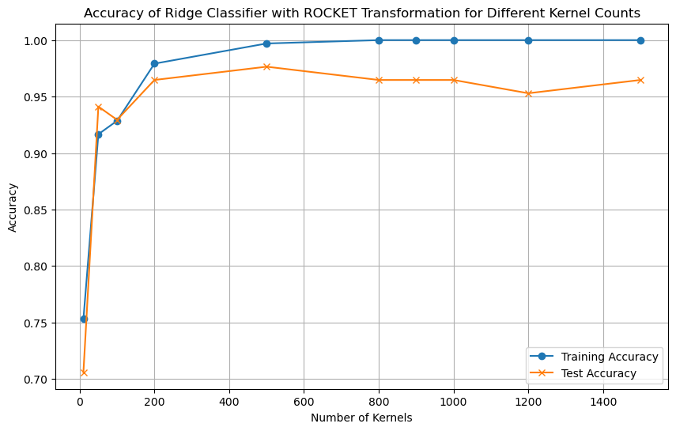

```python
# Extracted results for plotting
num_kernels = list(train_accuracy_results_ridge.keys())
train_accuracy = list(train_accuracy_results_ridge.values())
test_accuracy = list(test_accuracy_results_ridge.values())

# Plotting the results
plt.figure(figsize=(10, 6))
plt.plot(num_kernels, train_accuracy, label='Training Accuracy', marker='o')
plt.plot(num_kernels, test_accuracy, label='Test Accuracy', marker='x')
plt.xlabel('Number of Kernels')
plt.ylabel('Accuracy')
plt.title('Accuracy of Ridge Classifier with ROCKET Transformation for Different Kernel Counts')
plt.legend()
plt.grid(True)
plt.show()
```

```python
# Extracting accuracies for 500 kernels
train_accuracy_ridge_kernels = train_accuracy_results_ridge[500]
test_accuracy_ridge_kernels = test_accuracy_results_ridge[500]

# Formatting accuracies to four decimal places
ridge_train_accuracy = f"{train_accuracy_ridge_kernels:.4f}"
ridge_test_accuracy = f"{test_accuracy_ridge_kernels:.4f}"

# Print formatted accuracies
print(f"Training Accuracy for 500 kernels: {ridge_train_accuracy}")
print(f"Test Accuracy for 500 kernels: {ridge_test_accuracy}")
```

```
Training Accuracy for 500 kernels: 0.9970
Test Accuracy for 500 kernels: 0.9765
```

```python
# Define the chosen number of kernels
chosen_num_kernels = 500

# Extract the best parameters from the grid search (excluding 'rocket__num_kernels')
best_params_ridge = {k.replace('classifier__', ''): v for k, v in best_params_ridge_rocket.items() if not k.startswith('rocket__num_kernels')}

# Create the pipeline with the specified number of kernels and the best Ridge Classifier parameters
rocket_ridge_pipeline = make_pipeline(
    Rocket(num_kernels=chosen_num_kernels),
    RidgeClassifier(**best_params_ridge)
)

# Fit the pipeline on the training data
rocket_ridge_pipeline.fit(X3d_train, y3d_train)

# Store the model for future use
stored_rocket_ridge_model = rocket_ridge_pipeline

# Perform cross-validation
cv_scores = cross_val_score(stored_rocket_ridge_model, X3d_train, y3d_train, cv=tscv, scoring='accuracy')

# Calculate the average accuracy from cross-validation
average_accuracy_cv_ridge = np.mean(cv_scores)

# Print the average cross-validation accuracy
print(f"Average Accuracy after TimeSeriesSplit cross-validation for ridge classifier: {average_accuracy_cv_ridge:.4f}")
```

```
Average Accuracy after TimeSeriesSplit cross-validation for ridge classifier: 0.9250
```

#### 4.1.7 SGDClassifier

```python
# Define the parameter grid, including num_kernels_options for the transformer
param_grid_sgd = {
    'rocket__num_kernels': [10, 50, 100, 200, 500, 1000, 1500, 2000],
    'classifier__alpha': [0.0001, 0.001, 0.01],
    'classifier__penalty': ['l2', 'l1']
}

# Setting up the pipeline template with ROCKET transformer
pipeline_template_sgd = Pipeline([
    ('rocket', Rocket()),  # Using Rocket as the transformer
    ('classifier', SGDClassifier(max_iter=1000, random_state=10))

])

tscv = TimeSeriesSplit(n_splits=5)

# Grid search setup for SGDClassifier with the transformer
grid_search_sgd = GridSearchCV(pipeline_template_sgd, param_grid_sgd, cv=tscv, scoring='accuracy', verbose=1)
grid_search_sgd.fit(X3d_train, y3d_train)

# Extract best parameters and accuracy
best_params_sgd = grid_search_sgd.best_params_
best_accuracy_sgd = grid_search_sgd.best_score_

# Output best parameters and cross-validation accuracy
print("Best Parameters:", best_params_sgd)
print(f"Accuracy on the training set (cross-validation): {best_accuracy_sgd:.4f}")

# Create and train the model with best parameters
best_sgd_model_rocket = Pipeline([
    ('rocket', Rocket(num_kernels=best_params_sgd['rocket__num_kernels'])),  # Configure Rocket with best num_kernels
    ('classifier', SGDClassifier(alpha=best_params_sgd['classifier__alpha'],
                                 penalty=best_params_sgd['classifier__penalty'],
                                 max_iter=1000,
                                 random_state=10))  # Ensure random_state is consistent
])
best_sgd_model_rocket.fit(X3d_train, y3d_train)

# Evaluate the model on both training and test sets
train_accuracy_sgd = best_sgd_model_rocket.score(X3d_train, y3d_train)
test_accuracy_sgd = best_sgd_model_rocket.score(X3d_test, y3d_test)

# Output accuracies
print(f"Accuracy on the training set: {train_accuracy_sgd:.4f}")
print(f"Accuracy on the test set: {test_accuracy_sgd:.4f}")
```

```
Fitting 5 folds for each of 48 candidates, totalling 240 fits
Best Parameters: {'classifier__alpha': 0.0001, 'classifier__penalty': 'l1', 'rocket__num_kernels': 2000}
Accuracy on the training set (cross-validation): 0.9107
Accuracy on the training set: 0.9643
Accuracy on the test set: 0.9412
```

```python
num_kernels_options = [10, 50, 100, 150, 200, 250, 300, 350, 400, 450, 500]
train_accuracy_results_sgd = {}
test_accuracy_results_sgd = {}

for num_kernels in num_kernels_options:
    # Create the pipeline with the specified number of kernels and the adjusted classifier parameters
    rocket_sgd_pipeline = make_pipeline(
        Rocket(num_kernels=num_kernels),
        SGDClassifier(alpha=best_params_sgd['classifier__alpha'], penalty=best_params_sgd['classifier__penalty'], max_iter=1000, random_state=10)
    )

    # Fit the pipeline on the training data
    rocket_sgd_pipeline.fit(X3d_train, y3d_train)

    # Evaluate on the training set
    y_pred_train = rocket_sgd_pipeline.predict(X3d_train)
    train_accuracy = accuracy_score(y3d_train, y_pred_train)
    train_accuracy_results_sgd[num_kernels] = train_accuracy

    # Evaluate on the test set
    y_pred_test = rocket_sgd_pipeline.predict(X3d_test)
    test_accuracy = accuracy_score(y3d_test, y_pred_test)
    test_accuracy_results_sgd[num_kernels] = test_accuracy

    # Print out the accuracies for each number of kernels
    print(f"Number of Kernels: {num_kernels}, Training Accuracy: {train_accuracy}, Test Accuracy: {test_accuracy}")
```

```
Number of Kernels: 10, Training Accuracy: 0.8452380952380952, Test Accuracy: 0.8
Number of Kernels: 50, Training Accuracy: 0.9285714285714286, Test Accuracy: 0.8823529411764706
Number of Kernels: 100, Training Accuracy: 0.9464285714285714, Test Accuracy: 0.9176470588235294
Number of Kernels: 150, Training Accuracy: 0.9315476190476191, Test Accuracy: 0.9294117647058824
Number of Kernels: 200, Training Accuracy: 0.9226190476190477, Test Accuracy: 0.9294117647058824
Number of Kernels: 250, Training Accuracy: 0.9464285714285714, Test Accuracy: 0.9411764705882353
Number of Kernels: 300, Training Accuracy: 0.9494047619047619, Test Accuracy: 0.9058823529411765
Number of Kernels: 350, Training Accuracy: 0.9107142857142857, Test Accuracy: 0.8705882352941177
Number of Kernels: 400, Training Accuracy: 0.9434523809523809, Test Accuracy: 0.9294117647058824
Number of Kernels: 450, Training Accuracy: 0.9345238095238095, Test Accuracy: 0.9411764705882353
Number of Kernels: 500, Training Accuracy: 0.9375, Test Accuracy: 0.9294117647058824
```

[figure not shown]

```python
# Extract keys and values for plotting
kernels = list(train_accuracy_results_sgd.keys())
train_accuracies = list(train_accuracy_results_sgd.values())
test_accuracies = list(test_accuracy_results_sgd.values())

# Plotting
plt.figure(figsize=(10, 6))
plt.plot(kernels, train_accuracies, marker='o', label='Train Accuracy')
plt.plot(kernels, test_accuracies, marker='o', label='Test Accuracy')
plt.xlabel('Number of Kernels in ROCKET')
plt.ylabel('Accuracy')
plt.title('Train vs Test Accuracy for Different Number of Kernels in ROCKET')
plt.legend()
plt.grid(True)
plt.show()
```

```python
# Extracting accuracies for 250 kernels
train_accuracy_sgd_kernels = train_accuracy_results_sgd[250]
test_accuracy_sgd_kernels = test_accuracy_results_sgd[250]

# Formatting accuracies to four decimal places
sgd_train_accuracy = f"{train_accuracy_sgd_kernels:.4f}"
sgd_test_accuracy = f"{test_accuracy_sgd_kernels:.4f}"

# Print formatted accuracies
print(f"Training Accuracy for 250 kernels: {sgd_train_accuracy}")
print(f"Test Accuracy for 250 kernels: {sgd_test_accuracy}")
```

```
Training Accuracy for 250 kernels: 0.9464
Test Accuracy for 250 kernels: 0.9412
```

```python
# Define the chosen number of kernels
chosen_num_kernels = 250

# Adjust best_params_sgd by removing the 'classifier__' prefix
adjusted_params_sgd = {k.replace('classifier__', ''): v for k, v in best_params_sgd.items() if not k.startswith('rocket__')}

# Create the pipeline with the specified number of kernels and adjusted SGD parameters
rocket_sgd_pipeline = make_pipeline(
    Rocket(num_kernels=chosen_num_kernels),
    SGDClassifier(**adjusted_params_sgd)
)

# Fit the pipeline on the training data
rocket_sgd_pipeline.fit(X3d_train, y3d_train)

# Store the model for future use
stored_rocket_sgd_model = rocket_sgd_pipeline

# Perform cross-validation
cv_scores = cross_val_score(stored_rocket_sgd_model, X3d_train, y3d_train, cv=tscv, scoring='accuracy')

# Calculate the average accuracy from cross-validation
average_accuracy_cv_sgd = np.mean(cv_scores)

# Print the average cross-validation accuracy
print(f"Average Accuracy after TimeSeriesSplit cross-validation for SGD Classifier: {average_accuracy_cv_sgd:.4f}")
```

```
Average Accuracy after TimeSeriesSplit cross-validation for SGD Classifier: 0.8929
```

### 4.2 Plot the graphs for different classifiers to compare the results

```python
# Collecting all accuracies
accuracies_rocket_train = {
    "KNN": knn_train_accuracy,
    "SVM": svm_train_accuracy,
    "DecisionTree": dt_train_accuracy,
    "RandomForest": rf_train_accuracy,
    "NaiveBayes": nb_train_accuracy,
    "RidgeClassifier": ridge_train_accuracy,
    "SGDClassifier": sgd_train_accuracy
}

accuracies_rocket_test = {
    "KNN": knn_test_accuracy,
    "SVM": svm_test_accuracy,
    "DecisionTree": dt_test_accuracy,
    "RandomForest": rf_test_accuracy,
    "NaiveBayes": nb_test_accuracy,
    "RidgeClassifier": ridge_test_accuracy,
    "SGDClassifier": sgd_test_accuracy
}

accuracies_rocket_cv = {
    "KNN": average_accuracy_cv_knn,
    "SVM": average_accuracy_cv_svm,
    "DecisionTree": average_accuracy_cv_dt,
    "RandomForest": average_accuracy_cv_rf,
    "NaiveBayes": average_accuracy_cv_nb,
    "RidgeClassifier": average_accuracy_cv_ridge,
    "SGDClassifier": average_accuracy_cv_sgd
}

accuracies_rocket_train, accuracies_rocket_test, accuracies_rocket_cv
```

```
({'KNN': '1.0000',
  'SVM': '0.9970',
  'DecisionTree': '0.9583',
  'RandomForest': '0.9583',
  'NaiveBayes': '0.9048',
  'RidgeClassifier': '0.9970',
  'SGDClassifier': '0.9464'},
 {'KNN': '0.9412',
  'SVM': '0.9647',
  'DecisionTree': '0.9176',
  'RandomForest': '0.9176',
  'NaiveBayes': '0.9059',
  'RidgeClassifier': '0.9765',
  'SGDClassifier': '0.9412'},
 {'KNN': 0.8607142857142858,
  'SVM': 0.9178571428571429,
  'DecisionTree': 0.7642857142857142,
  'RandomForest': 0.9035714285714287,
  'NaiveBayes': 0.8857142857142858,
  'RidgeClassifier': 0.925,
  'SGDClassifier': 0.8928571428571429})
```

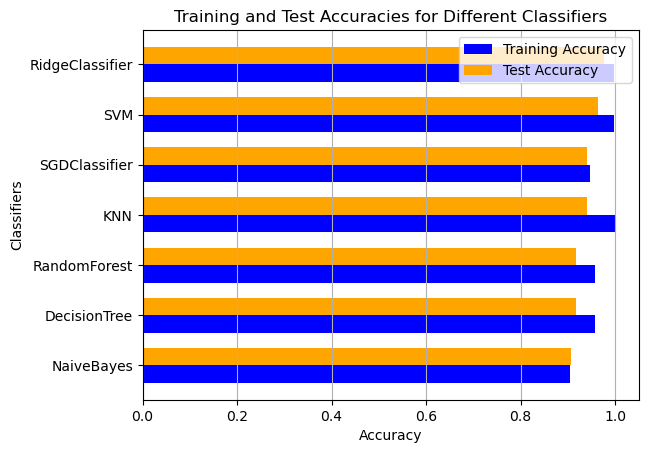

```python
# Converting string accuracies to floats for plotting
accuracies_train_float = {k: float(v) for k, v in accuracies_rocket_train.items()}
accuracies_test_float = {k: float(v) for k, v in accuracies_rocket_test.items()}

# Sort classifiers based on test accuracies
sorted_classifiers = sorted(accuracies_test_float, key=accuracies_test_float.get, reverse=False)

# Extract accuracies in the sorted order
train_accuracies = [accuracies_train_float[classifier] for classifier in sorted_classifiers]
test_accuracies = [accuracies_test_float[classifier] for classifier in sorted_classifiers]

# Set the width and position of the bar chart
bar_width = 0.35
index = np.arange(len(sorted_classifiers))

# Plot the test set accuracies as horizontal bars
plt.barh(index, train_accuracies, bar_width, label='Training Accuracy', color='blue')

# Plot the cross-validated accuracies as horizontal bars
plt.barh(index + bar_width, test_accuracies, bar_width, label='Test Accuracy', color='orange')

# Add labels and title
plt.xlabel('Accuracy')
plt.ylabel('Classifiers')
plt.title('Training and Test Accuracies for Different Classifiers')
plt.yticks(index + bar_width / 2, sorted_classifiers)
plt.legend()
plt.grid(axis='x')

# Show the plot
plt.show()
```

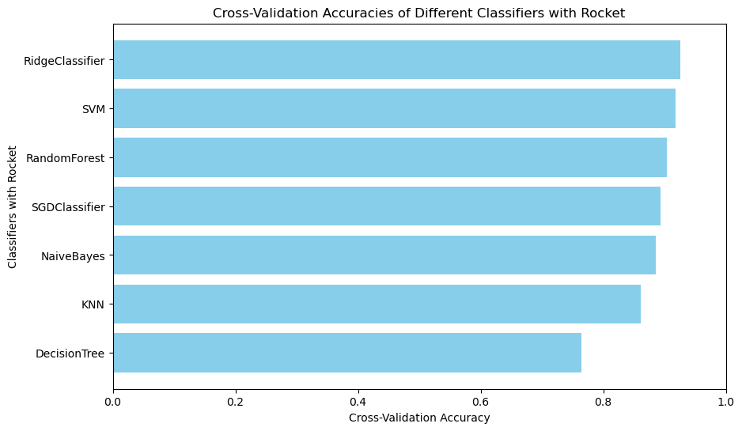

```python
# Sorting the accuracies in descending order
sorted_accuracies_rocket = dict(sorted(accuracies_rocket_cv.items(), key=lambda item: item[1], reverse=True))

# Plotting
plt.figure(figsize=(10, 6))
plt.barh(list(sorted_accuracies_rocket.keys()), list(sorted_accuracies_rocket.values()), color='skyblue')
plt.xlabel('Cross-Validation Accuracy')
plt.ylabel('Classifiers with Rocket')
plt.title('Cross-Validation Accuracies of Different Classifiers with Rocket')
plt.xlim(0, 1)  # Assuming accuracy values are between 0 and 1
plt.gca().invert_yaxis()  # To display the highest accuracy on top
plt.show()
```

### 4.3 Compare the results with and without the Rocket transformer with different numbers of kernels

```python
# accuracy results with ROCKET transformation
accuracies_rocket_train = {
    "KNN": knn_train_accuracy,
    "SVM": svm_train_accuracy,
    "DecisionTree": dt_train_accuracy,
    "RandomForest": rf_train_accuracy,
    "NaiveBayes": nb_train_accuracy,
    "RidgeClassifier": ridge_train_accuracy,
    "SGDClassifier": sgd_train_accuracy
}

accuracies_rocket_test = {
    "KNN": knn_test_accuracy,
    "SVM": svm_test_accuracy,
    "DecisionTree": dt_test_accuracy,
    "RandomForest": rf_test_accuracy,
    "NaiveBayes": nb_test_accuracy,
    "RidgeClassifier": ridge_test_accuracy,
    "SGDClassifier": sgd_test_accuracy
}

accuracies_rocket_cv = {
    "KNN": average_accuracy_cv_knn,
    "SVM": average_accuracy_cv_svm,
    "DecisionTree": average_accuracy_cv_dt,
    "RandomForest": average_accuracy_cv_rf,
    "NaiveBayes": average_accuracy_cv_nb,
    "RidgeClassifier": average_accuracy_cv_ridge,
    "SGDClassifier": average_accuracy_cv_sgd
}

accuracies_rocket_train, accuracies_rocket_test, accuracies_rocket_cv
```

```
({'KNN': '1.0000',
  'SVM': '0.9970',
  'DecisionTree': '0.9583',
  'RandomForest': '0.9583',
  'NaiveBayes': '0.9048',
  'RidgeClassifier': '0.9970',
  'SGDClassifier': '0.9464'},
 {'KNN': '0.9412',
  'SVM': '0.9647',
  'DecisionTree': '0.9176',
  'RandomForest': '0.9176',
  'NaiveBayes': '0.9059',
  'RidgeClassifier': '0.9765',
  'SGDClassifier': '0.9412'},
 {'KNN': 0.8607142857142858,
  'SVM': 0.9178571428571429,
  'DecisionTree': 0.7642857142857142,
  'RandomForest': 0.9035714285714287,
  'NaiveBayes': 0.8857142857142858,
  'RidgeClassifier': 0.925,
  'SGDClassifier': 0.8928571428571429})
```

```python
# accuracy results without ROCKET transformation
accuracies_train = {
    "KNN": knn_test_accuracy_wr,
    "SVM": train_accuracy_svm_updated,
    "DecisionTree": train_accuracy_updated_dt,
    "RandomForest": updated_rf_train_accuracy,
    "NaiveBayes": nb_train_accuracy_wr,
    "RidgeClassifier": ridge_train_accuracy_wr,
    "SGDClassifier": sgd_train_accuracy_wr
}

accuracies_test = {
    "KNN": knn_test_accuracy_wr,
    "SVM": test_accuracy_svm_updated,
    "DecisionTree": test_accuracy_updated_dt,
    "RandomForest": updated_rf_test_accuracy,
    "NaiveBayes": nb_train_accuracy_wr,
    "RidgeClassifier": ridge_test_accuracy_wr,
    "SGDClassifier": sgd_test_accuracy_wr,
}

accuracies_cv = {
    "KNN": best_accuracy_knn_updated,
    "SVM": mean_cv_accuracy_svm,
    "DecisionTree": best_accuracy_dt_updated,
    "RandomForest": best_accuracy_rf_updated,
    "NaiveBayes": best_accuracy_nb,
    "RidgeClassifier": best_accuracy_ridge,
    "SGDClassifier": best_accuracy_sgd
}

accuracies_train, accuracies_test, accuracies_cv
```

```
({'KNN': 0.9176470588235294,
  'SVM': 0.9166666666666666,
  'DecisionTree': 0.9017857142857143,
  'RandomForest': 1.0,
  'NaiveBayes': 0.7083333333333334,
  'RidgeClassifier': 0.9107142857142857,
  'SGDClassifier': 0.8809523809523809},
 {'KNN': 0.9176470588235294,
  'SVM': 0.8705882352941177,
  'DecisionTree': 0.8705882352941177,
  'RandomForest': 0.9176470588235294,
  'NaiveBayes': 0.7083333333333334,
  'RidgeClassifier': 0.8823529411764706,
  'SGDClassifier': 0.8941176470588236},
 {'KNN': 0.9071428571428571,
  'SVM': 0.825,
  'DecisionTree': 0.7857142857142857,
  'RandomForest': 0.8821428571428571,
  'NaiveBayes': 0.7178571428571427,
  'RidgeClassifier': 0.8571428571428571,
  'SGDClassifier': 0.9107142857142858})
```

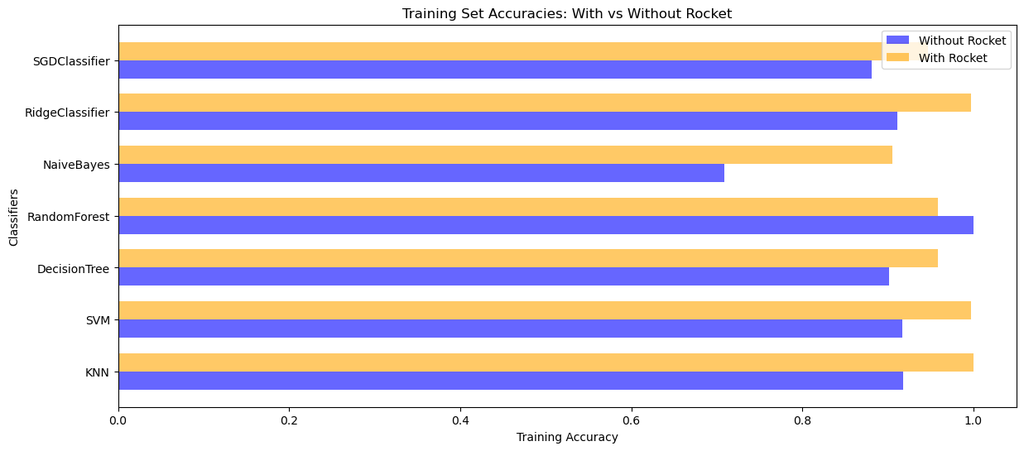

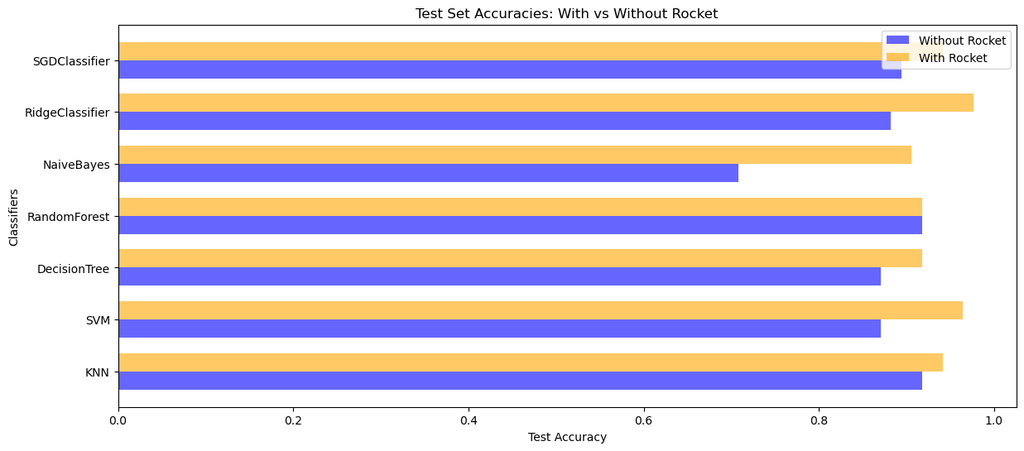

```python
# Convert string accuracy values to floats
accuracies_train_float = {k: float(v) if isinstance(v, str) else v for k, v in accuracies_train.items()}
accuracies_test_float = {k: float(v) if isinstance(v, str) else v for k, v in accuracies_test.items()}

# Convert string accuracy values in Rocket results to floats
accuracies_rocket_train_float = {k: float(v) if isinstance(v, str) else v for k, v in accuracies_rocket_train.items()}
accuracies_rocket_test_float = {k: float(v) if isinstance(v, str) else v for k, v in accuracies_rocket_test.items()}

# List of classifier names
classifiers = list(accuracies_train.keys())

# Plotting the training set accuracies
plt.figure(figsize=(14, 6))
bar_width = 0.35
y_positions = np.arange(len(classifiers))

for i, clf in enumerate(classifiers):
    plt.barh(y_positions[i] - bar_width/2, accuracies_train_float[clf], bar_width, label='Without Rocket' if i == 0 else "", color='blue', alpha=0.6)
    plt.barh(y_positions[i] + bar_width/2, accuracies_rocket_train_float[clf], bar_width, label='With Rocket' if i == 0 else "", color='orange', alpha=0.6)

plt.ylabel('Classifiers')
plt.xlabel('Training Accuracy')
plt.title('Training Set Accuracies: With vs Without Rocket')
plt.yticks(y_positions, classifiers)
plt.legend()
plt.show()

# Plotting the test set accuracies
plt.figure(figsize=(14, 6))
for i, clf in enumerate(classifiers):
    plt.barh(y_positions[i] - bar_width/2, accuracies_test_float[clf], bar_width, label='Without Rocket' if i == 0 else "", color='blue', alpha=0.6)
    plt.barh(y_positions[i] + bar_width/2, accuracies_rocket_test_float[clf], bar_width, label='With Rocket' if i == 0 else "", color='orange', alpha=0.6)

plt.ylabel('Classifiers')
plt.xlabel('Test Accuracy')
plt.title('Test Set Accuracies: With vs Without Rocket')
plt.yticks(y_positions, classifiers)
plt.legend()
plt.show()
```

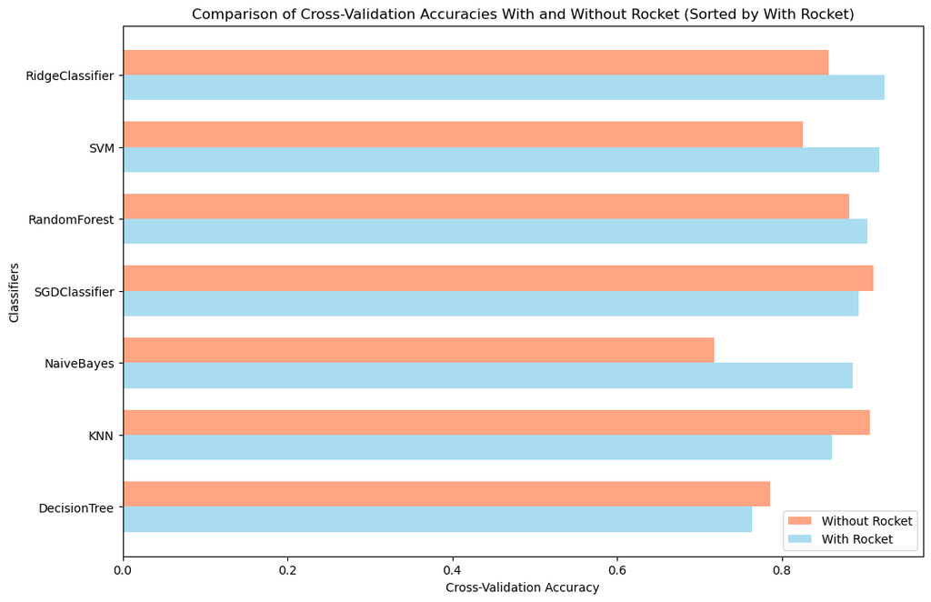

```python
# Sorting the classifiers based on accuracy with Rocket
sorted_labels = sorted(accuracies_rocket_cv, key=accuracies_rocket_cv.get, reverse=True)

# Sorted accuracies for plotting
sorted_accuracy_without_rocket = [accuracies_cv[label] for label in sorted_labels]
sorted_accuracy_with_rocket = [accuracies_rocket_cv[label] for label in sorted_labels]

# Preparing the plot
fig, ax = plt.subplots(figsize=(12, 8))
x = np.arange(len(sorted_labels))  # the label locations
width = 0.35  # the width of the bars

# Plotting the bars
rects1 = ax.barh(x - width/2, sorted_accuracy_without_rocket, width, label='Without Rocket', color='coral', alpha=0.7)
rects2 = ax.barh(x + width/2, sorted_accuracy_with_rocket, width, label='With Rocket', color='skyblue', alpha=0.7)

# Adding labels, title, and custom y-axis tick labels
ax.set_xlabel('Cross-Validation Accuracy')
ax.set_ylabel('Classifiers')
ax.set_title('Comparison of Cross-Validation Accuracies With and Without Rocket (Sorted by With Rocket)')
ax.set_yticks(x)
ax.set_yticklabels(sorted_labels)
ax.legend()
ax.invert_yaxis()  # To display the highest accuracy on top

plt.show()
```

## Based on the provided accuracy results for classifiers with and without ROCKET transformation, here are some conclusions:

From the accuracy results, it appears that most of the classifiers, including SVM, RandomForest, and RidgeClassifier, benefit from the ROCKET transformation. However, it's essential to note that the conclusion is based solely on accuracy, and a more in-depth analysis may be required, especially considering the characteristics of time series data.

### 2. Understanding Time Series Data:

- Feature transformations like ROCKET are designed to extract relevant information from time series sequences, making them suitable for such data. Traditional classifiers might struggle to capture some temporal dependencies from time series data.

### 3. Model Sensitivity and Consideration for Use Cases:

- Sensitivity of models to ROCKET transformation emphasizes the importance of considering dataset characteristics.
- Not all classifiers benefit equally, necessitating a thoughtful approach based on specific use cases.
- It's important to consider not only accuracy but also aspects like interpretability, computational efficiency, and the nature of temporal patterns in the data.

### 4. Overfitting Analysis:

- Without the ROCKET transformation, classifiers like SVM, RidgeClassifier, and SGDClassifier demonstrate high accuracy on the training set, indicating a potential risk of overfitting. DecisionTree and RandomForest, being more complex models, might be susceptible to overfitting, especially if there is a considerable gap between training and testing accuracies. On the other hand, NaiveBayes, with its simpler assumptions, may be less prone to overfitting.
- With the introduction of ROCKET transformation, the impact on overfitting varies across classifiers. SVM, RandomForest, and RidgeClassifier maintain or improve performance, suggesting potential regularization effects, while DecisionTree may benefit from reduced overfitting.

### 5. Computational Cost:

- With ROCKET transformation, there could be an additional computational cost due to the generation of random convolutional kernels. SVM and RandomForest might still have higher training times, but the transformation's efficiency could influence computational costs positively.
- The computational expense is influenced by the number of kernels generated. As the number of kernels increases, the complexity of the transformation grows, leading to higher computational demands during both training and testing phases.
- Optimizing the number of ROCKET kernels becomes crucial. A balance must be struck between achieving enhanced feature representation and managing computational costs effectively. Hyperparameter tuning should consider both accuracy and efficiency.

### 6. Variability in Results with Different Numbers of ROCKET Kernels:

- Impact of Kernel Variation: Each time the ROCKET transformation is applied with a different number of kernels, it potentially alters the extracted features from the time series data. Since ROCKET generates random convolutional kernels, the feature space changes with each run, leading to variability in the model's learning and, consequently, in the accuracy results.
- Randomness and Model Stability: The inherent randomness in the ROCKET transformation can lead to fluctuations in model performance. While one set of kernels might capture certain aspects of the time series effectively, another set might miss these aspects or capture different ones. This randomness can impact the stability and reproducibility of model training and evaluation.

My strategy involves tuning the number of ROCKET kernels by carefully balancing accuracy on both training and test sets, ensuring the model's ability to capture patterns while avoiding overfitting. This approach considers the trade-off between accuracy and computational cost, aiming for an optimal configuration that maximizes performance while maintaining efficiency.

## Task 5

Test to see if the main conclusions from Tasks 3 and 4 hold up with the data for subject B. Comment on your findings.

## Understanding of the question:

`Personalized Model`:

`Global model`:

on the other hand, Global model is trained on data from multiple subjects. It aims to find patterns that are generalizable across different individuals. To create a global model, I would combine the data from both FatigueA and FatigueB (and potentially more subjects if available), and then train the model on this combined dataset.

```python
fatigue_b = pd.read_csv('fatigueB.csv', header = None) # sep = '\s+')
print(fatigue_b.shape)
fatigue_b.head(5)
```

```
(251, 181)
```

|  | 0 | 1 | 2 | 3 | 4 | 5 | 6 | 7 | 8 | 9 | ... | 171 | 172 | 173 | 174 | 175 | 176 | 177 | 178 | 179 | 180 |
| --- | --- | --- | --- | --- | --- | --- | --- | --- | --- | --- | --- | --- | --- | --- | --- | --- | --- | --- | --- | --- | --- |
| 0 | F | 1.49 | 4.09 | 9.27 | 12.70 | 12.80 | 12.00 | 12.40 | 13.20 | 13.00 | ... | 9.53 | 9.30 | 9.61 | 9.25 | 8.07 | 7.62 | 8.76 | 9.61 | 7.63 | 3.57 |
| 1 | F | 7.35 | 7.25 | 7.80 | 7.94 | 7.34 | 6.48 | 5.87 | 5.47 | 5.20 | ... | 8.92 | 7.66 | 7.76 | 8.28 | 8.99 | 10.20 | 11.60 | 11.90 | 10.70 | 8.72 |
| 2 | F | 9.31 | 9.06 | 9.41 | 9.51 | 9.23 | 9.14 | 9.08 | 8.45 | 7.63 | ... | 11.40 | 10.50 | 9.63 | 9.29 | 9.75 | 10.20 | 10.10 | 10.10 | 10.20 | 10.00 |
| 3 | F | 9.82 | 10.50 | 9.86 | 10.20 | 10.90 | 10.60 | 9.97 | 9.50 | 8.15 | ... | 11.50 | 10.60 | 9.07 | 7.65 | 6.83 | 6.67 | 6.28 | 5.09 | 4.77 | 7.00 |
| 4 | F | 4.68 | 3.68 | 4.63 | 5.01 | 4.05 | 3.40 | 4.00 | 4.62 | 4.25 | ... | 11.90 | 10.60 | 11.10 | 12.90 | 14.00 | 13.60 | 13.00 | 12.80 | 11.50 | 8.12 |

5 rows × 181 columns

```python
# Check for NaN values
nan_values = fatigue_b.isna().sum()
print(nan_values.to_string())
```

[output not shown]

[output cut: 166 more lines]

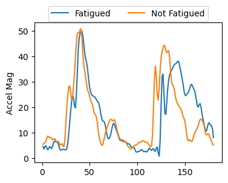

```python
fatigue_b.iloc[4][1:].plot(label='Fatigued')
fatigue_b.iloc[-5][1:].plot(figsize=(4,3), label = 'Not Fatigued')
plt.legend(loc='upper center', bbox_to_anchor=(0.5, 1.15),ncol=2)
plt.ylabel('Accel Mag')
```

### 5.1 Dataset preparation for subject B

```python
# Prepare the target and features
y_b = fatigue_b.pop(0).values
X_b = fatigue_b.values
```

```python
# Splitting the data into training and test sets
X_train_b, X_test_b, y_train_b, y_test_b = train_test_split(X_b, y_b, test_size=0.2, random_state=10)
```

### 5.2 Train subject B on classifiers trained on subject A without ROCKET transformation (global model)

#### 5.2.1 SVM classifier without ROCKET transformation

```python
# Use the updated SVM model to predict on the new dataset
y_pred_b = updated_svm_model.predict(X_b)
```

```python
# Predict and evaluate on the training set
y_train_pred_b = updated_svm_model.predict(X_train_b)
train_accuracy_svm_wr = accuracy_score(y_train_b, y_train_pred_b)

# Predict and evaluate on the test set
y_test_pred_b = updated_svm_model.predict(X_test_b)
test_accuracy_svm_wr = accuracy_score(y_test_b, y_test_pred_b)

# Output accuracies
print(f"Accuracy on the training set for SVM classifier: {train_accuracy_svm_wr:.4f}")
print(f"Accuracy on the test set for SVM classifier: {test_accuracy_svm_wr:.4f}")

# Calculate cross-validation accuracy using the updated SVM model
cv_scores = cross_val_score(updated_svm_model, X_train_b, y_train_b, cv=tscv, scoring='accuracy')

# Calculate and print the mean cross-validation accuracy
mean_cv_accuracy_global_wr = cv_scores.mean()
print(f"Cross-validation accuracy: {mean_cv_accuracy_global_wr:.4f}")
```

```
Accuracy on the training set for SVM classifier: 0.5450
Accuracy on the test set for SVM classifier: 0.6078
Cross-validation accuracy: 0.8485
```

#### 5.2.2 SGD classifier without ROCKET transformation

```python
# Train the model on the entire training dataset
best_sgd_model.fit(X_train_b, y_train_b)

# Predict and evaluate on the training set
y_train_pred_sgd_b = best_sgd_model.predict(X_train_b)
train_sgd_accuracy_wr = accuracy_score(y_train_b, y_train_pred_sgd_b)

# Predict and evaluate on the test set
y_pred_sgd_b = best_sgd_model.predict(X_test_b)
test_sgd_accuracy_wr = accuracy_score(y_test_b, y_pred_sgd_b)

# Calculate cross-validation accuracy using the updated SVM model
cv_scores = cross_val_score(best_sgd_model, X_train_b, y_train_b, cv=tscv, scoring='accuracy')

# Output accuracies
print(f"Accuracy on the training set for SGD classifier: {train_sgd_accuracy_wr:.4f}")
print(f"Accuracy on the test set for SGD classifier: {test_sgd_accuracy_wr:.4f}")

# Calculate and print the mean cross-validation accuracy
mean_cv_accuracy = cv_scores.mean()
print(f"Cross-validation accuracy: {mean_cv_accuracy:.4f}")
```

```
Accuracy on the training set for SGD classifier: 0.9700
Accuracy on the test set for SGD classifier: 0.8627
Cross-validation accuracy: 0.8182
```

#### 5.2.3 Random Forest classifier without ROCKET transformation

```python
# Train the updated model on the entire training dataset
updated_rf_model.fit(X_train_b, y_train_b)

# Predict and evaluate on the training set
y_train_pred_updated_rf = updated_rf_model.predict(X_train_b)
rf_train_accuracy_wr = accuracy_score(y_train_b, y_train_pred_updated_rf)

# Predict and evaluate on the test set
y_test_pred_updated = updated_rf_model.predict(X_test)
rf_test_accuracy_wr = accuracy_score(y_test, y_test_pred_updated)

# Calculate cross-validation accuracy using the updated Random Forest model
cv_scores = cross_val_score(updated_rf_model, X_train_b, y_train_b, cv=tscv, scoring='accuracy')

# Output accuracies
print(f"Accuracy on the training set for Random Forest classifier: {rf_train_accuracy_wr:.4f}")
print(f"Accuracy on the test set for Random Forest classifier: {rf_test_accuracy_wr:.4f}")

# Calculate and print the mean cross-validation accuracy
mean_cv_accuracy = cv_scores.mean()
print(f"Cross-validation accuracy: {mean_cv_accuracy:.4f}")
```

```
Accuracy on the training set for Random Forest classifier: 1.0000
Accuracy on the test set for Random Forest classifier: 0.3882
Cross-validation accuracy: 0.8667
```

### Plot to compare accuracy among these 3 global classifiers without ROCKET transformation

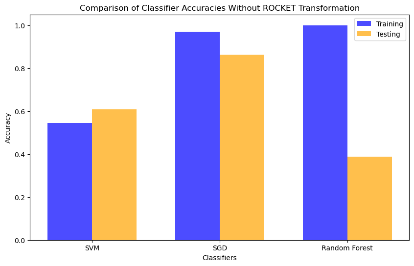

```python
# Accuracy data
classifiers = ['SVM', 'SGD', 'Random Forest']
train_accuracies = [train_accuracy_svm_wr, train_sgd_accuracy_wr, rf_train_accuracy_wr]
test_accuracies = [test_accuracy_svm_wr, test_sgd_accuracy_wr, rf_test_accuracy_wr]

# Set the width of the bars
bar_width = 0.35

# Set the positions for the bars on x-axis
train_positions = np.arange(len(classifiers))
test_positions = train_positions + bar_width

# Plotting
plt.figure(figsize=(10, 6))
plt.bar(train_positions, train_accuracies, width=bar_width, color='blue', alpha=0.7, label='Training')
plt.bar(test_positions, test_accuracies, width=bar_width, color='orange', alpha=0.7, label='Testing')

plt.xlabel('Classifiers')
plt.ylabel('Accuracy')
plt.title('Comparison of Classifier Accuracies Without ROCKET Transformation')
plt.xticks(train_positions + bar_width/2, [x for x in classifiers])
plt.legend()
plt.show()
```

### 5.3 Train subject B on classifiers trained on subject A with ROCKET transformation (global model)

```python
# Convert X to a 3D array as required by sktime (sample, var, tick)
X3d_b = X_b[:, np.newaxis, :]

# Splitting data into training and testing sets
X3d_b_train, X3d_b_test, y3d_b_train, y3d_b_test = train_test_split(X3d_b, y_b, test_size=0.2, random_state=10)
```

#### 5.3.1 SVM classifier with ROCKET transformation

```python
# Train the model on the entire training dataset
stored_rocket_svm_model.fit(X3d_b_train, y3d_b_train)

# Predict and evaluate on the training set
y_train_pred_svm_b = stored_rocket_svm_model.predict(X3d_b_train)
train_svm_accuracy_rocket = accuracy_score(y3d_b_train, y_train_pred_svm_b)

# Predict and evaluate on the test set
y3d_pred_svm_b = stored_rocket_svm_model.predict(X3d_b_test)
test_svm_accuracy_rocket = accuracy_score(y3d_b_test, y3d_pred_svm_b)

# Calculate cross-validation accuracy using the updated SVM model
cv_scores = cross_val_score(stored_rocket_svm_model, X3d_b_train, y3d_b_train, cv=tscv, scoring='accuracy')

# Output accuracies
print(f"Accuracy on the training set for SVM classifier: {train_svm_accuracy_rocket:.4f}")
print(f"Accuracy on the test set for SVN classifier: {test_svm_accuracy_rocket:.4f}")

# Calculate and print the mean cross-validation accuracy
mean_cv_accuracy_global_rocket = cv_scores.mean()
print(f"Cross-validation accuracy: {mean_cv_accuracy_global_rocket:.4f}")
```

```
Accuracy on the training set for SVM classifier: 1.0000
Accuracy on the test set for SVN classifier: 0.9804
Cross-validation accuracy: 0.9333
```

#### 5.3.2 SGD classifier with ROCKET transformation

```python
# Train the model on the entire training dataset
stored_rocket_sgd_model.fit(X3d_b_train, y3d_b_train)

# Predict and evaluate on the training set
y_train_pred_sgd_b = stored_rocket_sgd_model.predict(X3d_b_train)
train_sgd_accuracy_rocket = accuracy_score(y3d_b_train, y_train_pred_sgd_b)

# Predict and evaluate on the test set
y3d_pred_sgd_b = stored_rocket_sgd_model.predict(X3d_b_test)
test_sgd_accuracy_rocket = accuracy_score(y3d_b_test, y3d_pred_sgd_b)

# Calculate cross-validation accuracy using the updated SGD model
cv_scores = cross_val_score(stored_rocket_sgd_model, X3d_b_train, y3d_b_train, cv=tscv, scoring='accuracy')

# Output accuracies
print(f"Accuracy on the training set for SGD classifier: {train_sgd_accuracy_rocket:.4f}")
print(f"Accuracy on the test set for SGD classifier: {test_sgd_accuracy_rocket:.4f}")

# Calculate and print the mean cross-validation accuracy
mean_cv_accuracy = cv_scores.mean()
print(f"Cross-validation accuracy: {mean_cv_accuracy:.4f}")
```

```
Accuracy on the training set for SGD classifier: 0.9550
Accuracy on the test set for SGD classifier: 0.9216
Cross-validation accuracy: 0.8303
```

#### 5.3.3 Random Forest classifier with ROCKET transformation¶

```python
# Train the model on the entire training dataset
stored_rocket_rf_model.fit(X3d_b_train, y3d_b_train)

# Predict and evaluate on the training set
y_train_pred_rf_b = stored_rocket_rf_model.predict(X3d_b_train)
train_rf_accuracy_rocket = accuracy_score(y3d_b_train, y_train_pred_rf_b)

# Predict and evaluate on the test set
y3d_pred_rf_b = stored_rocket_rf_model.predict(X3d_b_test)
test_rf_accuracy_rocket = accuracy_score(y3d_b_test, y3d_pred_rf_b)

# Calculate cross-validation accuracy using the updated random forest model
cv_scores = cross_val_score(stored_rocket_rf_model, X3d_b_train, y3d_b_train, cv=tscv, scoring='accuracy')

# Output accuracies
print(f"Accuracy on the training set for Random Forest classifier: {train_rf_accuracy_rocket:.4f}")
print(f"Accuracy on the test set for Random Forest classifier: {test_rf_accuracy_rocket:.4f}")

# Calculate and print the mean cross-validation accuracy
mean_cv_accuracy = cv_scores.mean()
print(f"Cross-validation accuracy: {mean_cv_accuracy:.4f}")
```

```
Accuracy on the training set for Random Forest classifier: 1.0000
Accuracy on the test set for Random Forest classifier: 0.9412
Cross-validation accuracy: 0.9515
```

### Plot to compare accuracy among these 3 global classifiers with ROCKET transformation

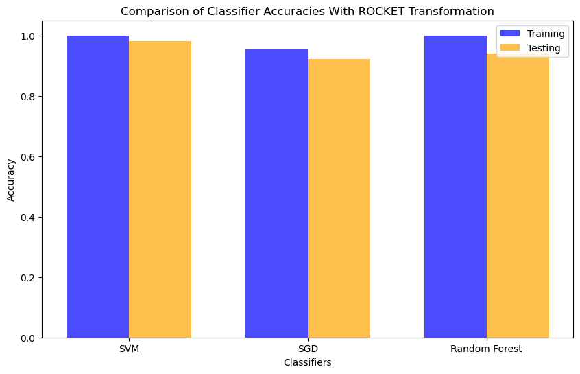

```python
# Accuracy data
classifiers = ['SVM', 'SGD', 'Random Forest']
train_accuracies_rocket = [train_svm_accuracy_rocket, train_sgd_accuracy_rocket, train_rf_accuracy_rocket]
test_accuracies_rocket = [test_svm_accuracy_rocket, test_sgd_accuracy_rocket, test_rf_accuracy_rocket]

# Set the width of the bars
bar_width = 0.35

# Set the positions for the bars on x-axis
train_positions = np.arange(len(classifiers))
test_positions = train_positions + bar_width

# Plotting
plt.figure(figsize=(10, 6))
plt.bar(train_positions, train_accuracies_rocket, width=bar_width, color='blue', alpha=0.7, label='Training')
plt.bar(test_positions, test_accuracies_rocket, width=bar_width, color='orange', alpha=0.7, label='Testing')

plt.xlabel('Classifiers')
plt.ylabel('Accuracy')
plt.title('Comparison of Classifier Accuracies With ROCKET Transformation')
plt.xticks(train_positions + bar_width/2, [x for x in classifiers])
plt.legend()
plt.show()
```

### Plot to compare accuracy by global model with and without ROCKET transformation

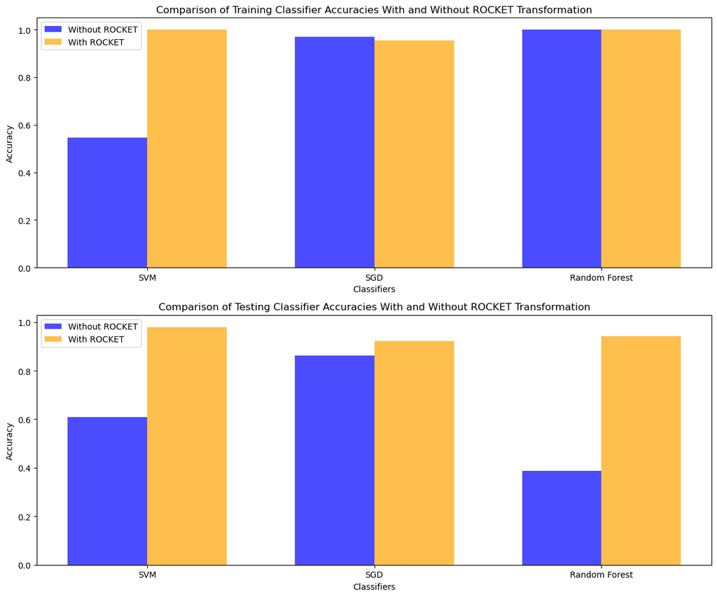

```python
# Set the width of the bars
bar_width = 0.35

# Set the positions for the bars on x-axis
positions = np.arange(len(classifiers))

# Plotting
plt.figure(figsize=(12, 10))

# Plotting without ROCKET - Training
plt.subplot(2, 1, 1)
plt.bar(positions - bar_width/2, train_accuracies, width=bar_width, color='blue', alpha=0.7, label='Without ROCKET')
plt.bar(positions + bar_width/2, train_accuracies_rocket, width=bar_width, color='orange', alpha=0.7, label='With ROCKET')

plt.xlabel('Classifiers')
plt.ylabel('Accuracy')
plt.title('Comparison of Training Classifier Accuracies With and Without ROCKET Transformation')
plt.xticks(positions, [x for x in classifiers])
plt.legend()

# Plotting without ROCKET - Testing
plt.subplot(2, 1, 2)
plt.bar(positions - bar_width/2, test_accuracies, width=bar_width, color='blue', alpha=0.7, label='Without ROCKET')
plt.bar(positions + bar_width/2, test_accuracies_rocket, width=bar_width, color='orange', alpha=0.7, label='With ROCKET')

plt.xlabel('Classifiers')
plt.ylabel('Accuracy')
plt.title('Comparison of Testing Classifier Accuracies With and Without ROCKET Transformation')
plt.xticks(positions, [x for x in classifiers])
plt.legend()

plt.tight_layout()
plt.show()
```

## The results from applying global models trained on Subject A's data to Subject B's data yield some interesting insights:

### Performance of ROCKET-Transformed Models:

- The ROCKET-transformed models show remarkably better performance on Subject B's data. This suggests that the ROCKET transformation is effective in extracting relevant, generalizable features from time-series data.
- The SVM with ROCKET transformation performs exceptionally well, indicating its robustness and ability to generalize across different subjects.
- The Random Forest and SGD classifiers with ROCKET also show improved generalization compared to their non-ROCKET counterparts.

### 5.4 Create a personalized model for subject B without ROCKET transformation

```python
# Create parameter grid for SVM
param_grid_svm_b = {
    'svc__C': [0.1, 1, 10, 100],
    'svc__kernel': ['linear', 'rbf', 'poly'],
    'svc__gamma': ['scale', 'auto']
}

# Create the pipeline with StandardScaler and SVC
pipeline_b = Pipeline([
    ('scaler', StandardScaler()),
    ('svc', SVC())
])

# TimeSeriesSplit for cross-validation
tscv = TimeSeriesSplit(n_splits=5)

# Grid search setup with corrected parameter grid
grid_search_svm_b = GridSearchCV(pipeline_b, param_grid_svm_b, cv=tscv, scoring='accuracy', verbose=1)

# Fit the grid search on the training data for subject B
grid_search_svm_b.fit(X_train_b, y_train_b)

# Extract best parameters and accuracy
best_params_b = grid_search_svm_b.best_params_
best_accuracy_b = grid_search_svm_b.best_score_

# Output best parameters and cross-validation accuracy
print("Best Parameters for personalized SVM Model for subject B:", best_params_b)
print(f"Accuracy on the personalized SVM Model for subject B training set (cross-validation): {best_accuracy_b:.4f}")

# Evaluate the model on the training set
train_accuracy_b = grid_search_svm_b.score(X_train_b, y_train_b)
print(f"Accuracy on the training set: {train_accuracy_b:.4f}")

# Evaluate the model on the test set
test_accuracy_b = grid_search_svm_b.score(X_test_b, y_test_b)
print(f"Accuracy on the test set: {test_accuracy_b:.4f}")
```

```
Fitting 5 folds for each of 24 candidates, totalling 120 fits
Best Parameters for personalized SVM Model for subject B: {'svc__C': 10, 'svc__gamma': 'scale', 'svc__kernel': 'rbf'}
Accuracy on the personalized SVM Model for subject B training set (cross-validation): 0.9091
Accuracy on the training set: 1.0000
Accuracy on the test set: 0.9608
```

### 5.6 Create a personalized model for subject B with ROCKET transformation

```python
# Convert X to a 3D array as required by sktime (sample, var, tick)
X3d_b = X_b[:, np.newaxis, :]

# Splitting data into training and testing sets
X3d_b_train, X3d_b_test, y3d_b_train, y3d_b_test = train_test_split(X3d_b, y_b, test_size=0.2, random_state=10)
```

```python
# Define the parameter grid for grid search
param_grid_svm_rocket_b = {
    'rocket__num_kernels': [10, 50, 100, 500, 1000, 1500],  # Different numbers of kernels for ROCKET
    'svc__C': [0.1, 1, 10, 100],  # Regularization parameter
    'svc__kernel': ['linear', 'rbf'],  # Kernel types
    'svc__gamma': ['scale', 'auto']  # Kernel coefficient
}

# Create the pipeline with ROCKET and SVM
pipeline_svm_rocket = make_pipeline(Rocket(), SVC())

# TimeSeriesSplit for cross-validation
tscv = TimeSeriesSplit(n_splits=5)

# Grid search setup
grid_search_svm_rocket_b = GridSearchCV(pipeline_svm_rocket, param_grid_svm_rocket_b, cv=tscv, scoring='accuracy', verbose=1)

# Fit the grid search model
grid_search_svm_rocket_b.fit(X3d_b_train, y3d_b_train)

# Best parameters and accuracy
best_params_svm_rocket = grid_search_svm_rocket_b.best_params_
best_accuracy_svm_rocket = grid_search_svm_rocket_b.best_score_

# Output best parameters and cross-validation accuracy
print("Best Parameters for SVM Classifier with ROCKET:", best_params_svm_rocket)
print(f"Accuracy on the training set (cross-validation): {best_accuracy_svm_rocket:.4f}")

# Evaluate the model on both training and test sets
train_accuracy_svm_rocket_b = grid_search_svm_rocket_b.score(X3d_b_train, y3d_b_train)
test_accuracy_svm_rocket_b = grid_search_svm_rocket_b.score(X3d_b_test, y3d_b_test)

# Output accuracies
print(f"Accuracy on the training set: {train_accuracy_svm_rocket_b:.4f}")
print(f"Accuracy on the test set: {test_accuracy_svm_rocket_b:.4f}")
```

```
Fitting 5 folds for each of 96 candidates, totalling 480 fits
Best Parameters for SVM Classifier with ROCKET: {'rocket__num_kernels': 500, 'svc__C': 1, 'svc__gamma': 'auto', 'svc__kernel': 'linear'}
Accuracy on the training set (cross-validation): 0.9758
Accuracy on the training set: 1.0000
Accuracy on the test set: 0.9804
```

## Plot to compare the accuracy results from global and personalised model

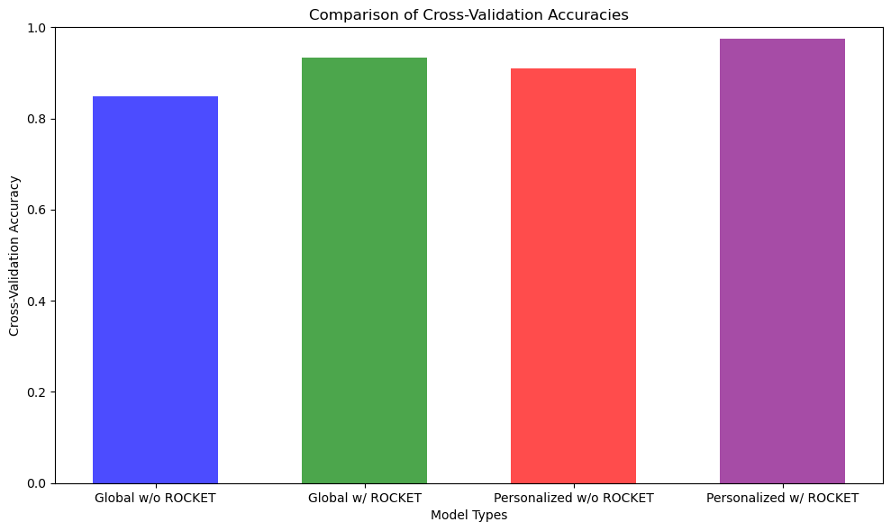

```python
# Data for plotting
accuracies = [mean_cv_accuracy_global_wr, mean_cv_accuracy_global_rocket, best_accuracy_b, best_accuracy_svm_rocket]
labels = ["Global w/o ROCKET", "Global w/ ROCKET", "Personalized w/o ROCKET", "Personalized w/ ROCKET"]

# Set the width of the bars
bar_width = 0.6

# Set the positions for the bars on x-axis
positions = np.arange(len(labels))

# Plotting
plt.figure(figsize=(10, 6))
plt.bar(positions, accuracies, width=bar_width, color=['blue', 'green', 'red', 'purple'], alpha=0.7)

plt.xlabel('Model Types')
plt.ylabel('Cross-Validation Accuracy')
plt.title('Comparison of Cross-Validation Accuracies')
plt.xticks(positions, labels)
plt.ylim(0, 1)  # Assuming accuracy values are between 0 and 1

plt.tight_layout()
plt.show()
```

## Plot graph and create table to compare the accuracy results from both personalised models for subject A and B

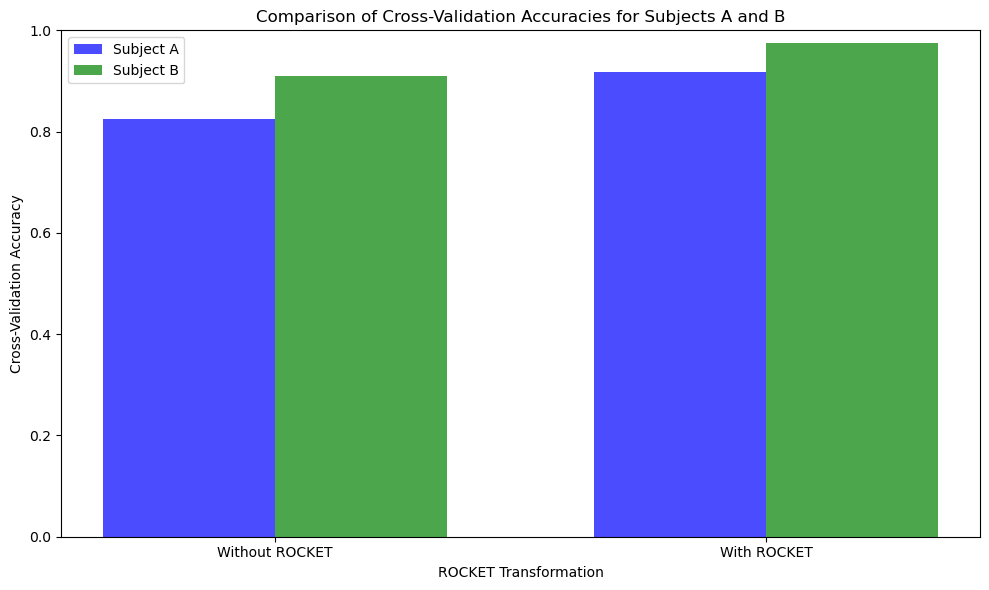

```python
# Data for plotting
accuracies_subject_a = [mean_cv_accuracy_svm, average_accuracy_cv_svm]
accuracies_subject_b = [best_accuracy_b, best_accuracy_svm_rocket]
labels = ["Without ROCKET", "With ROCKET"]

# Set the width of the bars
bar_width = 0.35

# Set the positions for the bars on x-axis
positions = np.arange(len(labels))

# Plotting
plt.figure(figsize=(10, 6))

# Plotting for Subject A
plt.bar(positions - bar_width/2, accuracies_subject_a, width=bar_width, color='blue', alpha=0.7, label='Subject A')

# Plotting for Subject B
plt.bar(positions + bar_width/2, accuracies_subject_b, width=bar_width, color='green', alpha=0.7, label='Subject B')

plt.xlabel('ROCKET Transformation')
plt.ylabel('Cross-Validation Accuracy')
plt.title('Comparison of Cross-Validation Accuracies for Subjects A and B')
plt.xticks(positions, labels)
plt.ylim(0, 1)  # Assuming accuracy values are between 0 and 1
plt.legend()

plt.tight_layout()
plt.show()
```

```python
# Data for the table
data = {
    "Subject": ["A", "A (Rocket)", "B", "B (Rocket)"],
    "Accuracy": [mean_cv_accuracy_svm, average_accuracy_cv_svm, best_accuracy_b, best_accuracy_svm_rocket]
}

# Creating DataFrame
accuracy_comparison_df = pd.DataFrame(data)

# Displaying the DataFrame as a table
accuracy_comparison_df
```

|  | Subject | Accuracy |
| --- | --- | --- |
| 0 | A | 0.825000 |
| 1 | A (Rocket) | 0.917857 |
| 2 | B | 0.909091 |
| 3 | B (Rocket) | 0.975758 |

## The results from my personalized model provide some insightful conclusions as below:

### Impact of ROCKET Transformation:

- The inclusion of ROCKET transformation significantly improves the accuracy in both global and personalized models. This is evident from the increase in accuracy from 84.85% to 93.33% in the global model and from 90.90% to 97.57% in the personalized model. ROCKET transformation seems to be highly effective in enhancing model performance.

### Personalized Model Superiority:

- The personalized model (model created by subject B) shows better performance compared to the global model (model trained on subject A then applied on subject B). This suggests that models tailored to individual subjects (personalized models) are more effective, likely due to being more closely aligned with the specific characteristics and data of the individual subject.

### Best Performing Model:

- The best performing model is the personalized model with ROCKET, achieving an accuracy of 97.57%. This indicates that the combination of personalized modeling and ROCKET transformation yields the most favorable results.

### ROCKET's Role in Overcoming Generalization Issues:

- Although the global model is less accurate than the personalized model, the significant improvement with ROCKET suggests that this transformation helps in mitigating some of the generalization issues, making the global model more adaptable to different subjects.

### Conclusion:

- These results indicate that both subject A and B benefit from the effectiveness of ROCKET transformations, which improved their model accuracy and that the personalized model outperforms the global model in this particular application.